# Digital Financial Literacy and Financial Well-Being: The Mediating Role of Financial Self-Efficacy among Students at Visayas State University

Author

ViSERDAC

Published

May 20, 2026

# 1 Attachments

**Note**

Copies of the Figures presented in this report are available using the links below. All the files can be accessed in the Google drive folder.

1. [Plots](https://drive.google.com/drive/folders/19CCug3KhxbFnaAqMjwSfKMinFN9ZMHWd?usp=sharing)
2. [Google Drive](https://drive.google.com/drive/folders/11C7ZeBVGgxZ_KQs1v6cQBP6qDIi4_toc?usp=sharing)

# 2 Objective 1: Present the socio-demographic profile of the respondents.

## 2.1 Sociodemographic variables

**TipInterpretations**

- **Age**
  - Median age is 20 years (IQR: 19–22), showing that most respondents are young adults, typical of undergraduate populations.
- **Sex**
  - Majority are female (65%), with males making up 35%. This gender distribution suggests a female-dominated sample, which may influence perspectives on financial literacy and well-being.
- **Degree Program**
  - Respondents come from diverse programs, but the largest groups are BS in Agribusiness (36%) and BS in Agriculture (23%), followed by Bachelor of Secondary Education (15%). There is a strong representation from agriculture-related disciplines, aligning with the institutional context.
- **Year Level**
  - Distribution is fairly balanced: 28% first year, 24% second year, 22% third year, and 26% fourth year and above.
- **Monthly Income/Allowance**
  - Majority (55%) receive ₱1,001–₱5,000, while 35% live on less than ₱1,000. Only 10% receive more than ₱5,000. This highlights financial constraints among students, with most operating on modest allowances.
- **Source of Financial Support**
  - Predominantly from parents/family (94%), with small proportions from scholarships (3.2%) and part-time jobs (2.7%). The result shows high dependence on family support, with limited self-generated income.
- **Type of Residence**
  - Nearly half (45%) live with parents/relatives, while 34% stay in boarding houses and 19% in dormitories. Result reflects a mix of home-based and independent living arrangements, which may affect financial management practices.

```r
## create a gt summary table
df |>
  select(age:residence_type) |>
  tbl_summary(
    statistic = list(all_categorical() ~ "{n} ({p}%)"),
    missing = "no",
    label = list(
      age ~ "Age",
      sex ~ "Sex",
      degree_program ~ "Degree Program",
      year_level ~ "Year level",
      monthly_income_allowance ~ "Monthly Income/Allowance",
      primary_source_of_financial_support = "Source of financial support",
      residence_type = "Type of residence"
    )
  ) |>
  bold_labels() %>%
  as_kable_extra(linesep = "") %>%
  kable_minimal() %>%
  kable_styling(
    full_width = F,
    fixed_thead = T,
    bootstrap_options = c("striped", "hover", "condensed", "responsive")
  )
```

| Characteristic | N = 370 |
| --- | --- |
| Age | 20.00 (19.00, 22.00) |
| Sex |  |
| Female | 241 (65%) |
| Male | 129 (35%) |
| Degree Program |  |
| AB in Philosophy | 2 (0.5%) |
| Bachelor of Culture and Arts Education | 1 (0.3%) |
| Bachelor of Secondary Education | 56 (15%) |
| BS in Agribusiness | 134 (36%) |
| BS in Agricultural and Biosystems Engineering | 10 (2.7%) |
| BS in Agriculture | 84 (23%) |
| BS in Biology | 2 (0.5%) |
| BS in Biotechnology | 2 (0.5%) |
| BS in Chemistry | 2 (0.5%) |
| BS in Civil Engineering | 5 (1.4%) |
| BS in Computer Science | 8 (2.2%) |
| BS in Development Communication | 10 (2.7%) |
| BS in Economics | 6 (1.6%) |
| BS in Environmental Science | 2 (0.5%) |
| BS in Food Technology | 2 (0.5%) |
| BS in Forestry | 16 (4.3%) |
| BS in Geodetic Engineering | 10 (2.7%) |
| BS in Hospitality Management | 4 (1.1%) |
| BS in Marine Biology | 6 (1.6%) |
| BS in Mechanical Engineering | 3 (0.8%) |
| BS in Meteorology | 1 (0.3%) |
| BS in Statistics | 2 (0.5%) |
| BS in Tourism Management | 1 (0.3%) |
| Doctor of Veterinary Medicine | 1 (0.3%) |
| Year level |  |
| 1st Year | 105 (28%) |
| 2nd Year | 89 (24%) |
| 3rd Year | 81 (22%) |
| 4th Year and above | 95 (26%) |
| Monthly Income/Allowance |  |
| ₱ 1,001 to ₱ 5,000 | 202 (55%) |
| ₱ 10,001 and above | 4 (1.1%) |
| ₱ 5,001 to ₱ 10,000 | 34 (9.2%) |
| Below ₱ 1,000 | 130 (35%) |
| Source of financial support |  |
| Business | 1 (0.3%) |
| Parents/Family | 346 (94%) |
| Part-time Job | 10 (2.7%) |
| Scholarship/Grant | 12 (3.2%) |
| SSS Survivorship Benefit | 1 (0.3%) |
| Type of residence |  |
| Apartment | 3 (0.8%) |
| Boarding House | 127 (34%) |
| Dormitory | 72 (19%) |
| Own House | 2 (0.5%) |
| With Parents/Relatives | 166 (45%) |

<sup>1</sup> Median (Q1, Q3); n (%)

## 2.2 Factors

### Awareness

**TipInterpretation**

- 61% strongly agree and 26% agree that they are aware of services like e-wallets, mobile banking, and online payment platforms. Only 2% strongly disagree and 2% disagree, showing very few respondents lack awareness.
- 46% strongly agree and 39% agree that they understand the specific purpose and usage of digital financial services However, 12% remain neutral, and about 3% disagree/strongly disagree, suggesting some uncertainty in deeper comprehension.
- 49% strongly agree and 36% agree that they are aware of potential risks. 12% are neutral, and 3% disagree/strongly disagree, indicating that while most recognize risks, a notable minority are unsure.
- Awareness of existence of services (adfs1) is the strongest (nearly 9 in 10 respondents agree/strongly agree). Awareness of purpose/usage (adfs2) is slightly lower, with more respondents neutral.

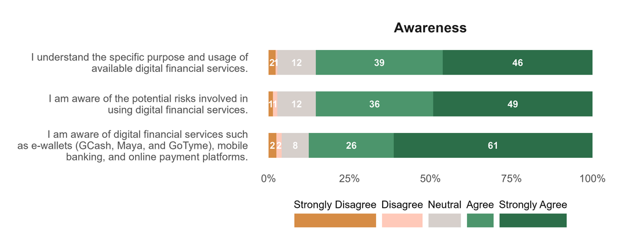

```r
p_awareness <- plot_factor("Awareness")

## saving plot
ggsave(
  plot = p_awareness,
  filename = "plot/fct_awareness.jpeg",
  width = 10,
  height = 4,
  dpi = 400,
  unit = "in"
)

## display plot
knitr::include_graphics("plot/fct_awareness.jpeg")
```

### Basic Knowledge and Skills

**TipInterpretation**

- Majority agree/strongly agree (68%) that they prepare a personal budget. However, 28% are neutral, suggesting that while budgeting is common, consistency may be lacking.
- 74% agree/strongly agree they shop online. Only 8% disagree, showing that digital consumption is widely practiced.
- 52% agree/strongly agree, but 34% are neutral and 9% disagree. While mobile banking is used, a significant portion remains hesitant or undecided.
- Nearly half (48%) are neutral about rarely making impulse purchases. Results indicate uncertainty or inconsistency in self-control over spending.
- There is a moderate understanding of financial numeracy concepts among respondents. For loan interest, 43% remained neutral while only 31% agreed or strongly agreed. Similarly, when asked about the future value of money, 39% were neutral and 47% agreed or strongly agreed.
- In contrast, investment decision-making showed stronger comprehension, with 69% agreeing or strongly agreeing. Highlighting that students feel more capable when evaluating investment choices compared to technical calculations of interest or future value.
- There is a very high level of digital literacy competence among respondents. For online search, 85% agreed or strongly agreed that they can effectively conduct searches using their devices, while only a small minority expressed disagreement or uncertainty.
- Similarly, email use (bks9) showed equally strong results, with 85% agreeing or strongly agreeing that they can send and receive emails independently.

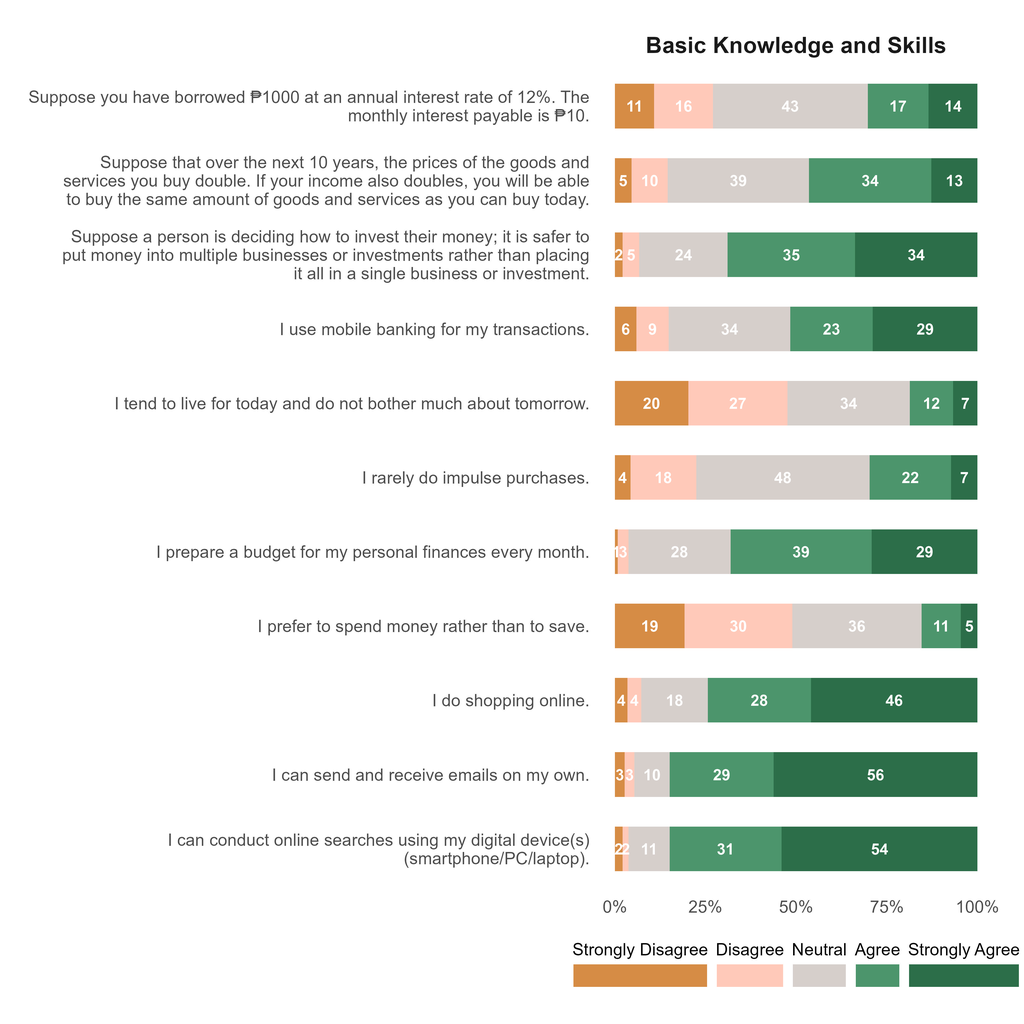

```r
p_basic_know_skill <- plot_factor("Basic Knowledge and Skills", stwidth = 70)

## saving plot
ggsave(
  plot = p_basic_know_skill,
  filename = "plot/fct_basic_know_skill.jpeg",
  width = 10,
  height = 10,
  dpi = 400,
  unit = "in"
)

## display plot
knitr::include_graphics("plot/fct_basic_know_skill.jpeg")
```

### Decision Making

**TipInterpretation**

- 39% agree and 18% strongly agree, showing more than half of respondents actively plan while managing daily finances. However, 37% are neutral and 7% disagree/strongly disagree, indicating that a significant group may not consistently integrate long-term planning into their financial routines.
- 43% agree and 26% strongly agree, meaning nearly 7 in 10 respondents report responsible behaviors like saving and borrowing wisely. Neutral responses (27%) suggest some uncertainty or inconsistency in applying these practices.
- 44% agree and 23% strongly agree, showing that two-thirds of respondents feel confident in selecting reliable providers for remittances, savings, or borrowing. Still, 27% are neutral and 6% disagree/strongly disagree, reflecting that not all students are fully confident in navigating digital financial platforms.

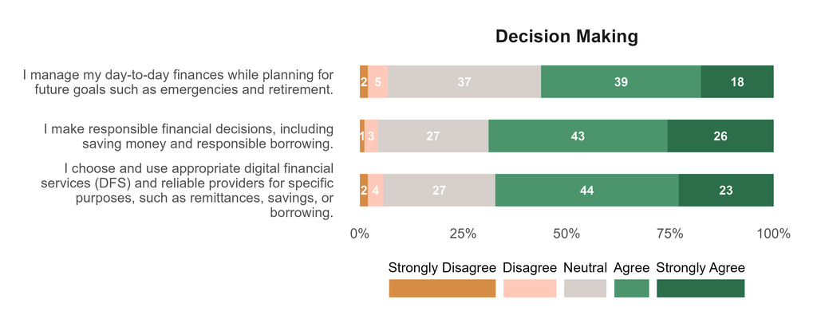

```r
p_decision_making <- plot_factor("Decision Making")

## saving plot
ggsave(
  plot = p_decision_making,
  filename = "plot/fct_decision_making.jpeg",
  width = 10,
  height = 4,
  dpi = 400,
  unit = "in"
)

## display plot
knitr::include_graphics("plot/fct_decision_making.jpeg")
```

### Financial Anxiety

**TipInterpretation**

- 37% agree and 15% strongly agree they are comfortable managing transactions with banks and financial institutions using digital payment solutions. However, 41% are neutral and 7% disagree/strongly disagree, showing that while many feel confident, a large group remains uncertain.
- 34% agree and 14% strongly agree that unexpected events disrupt their financial control when using online payment options. 42% are neutral, suggesting that many students experience occasional disruptions but may not perceive them as constant or severe.
- 27% agree and 8% strongly agree they find it difficult to live fully because of extreme concern over monitoring digital transactions. Yet, 43% are neutral and 21% disagree/strongly disagree, indicating that financial anxiety is present but not dominant across the group.
- 23% agree and 7% strongly agree that digital payment methods completely control their financial life. The largest group (42%) is neutral, while 28% disagree/strongly disagree, showing mixed perceptions of control, with many undecided.

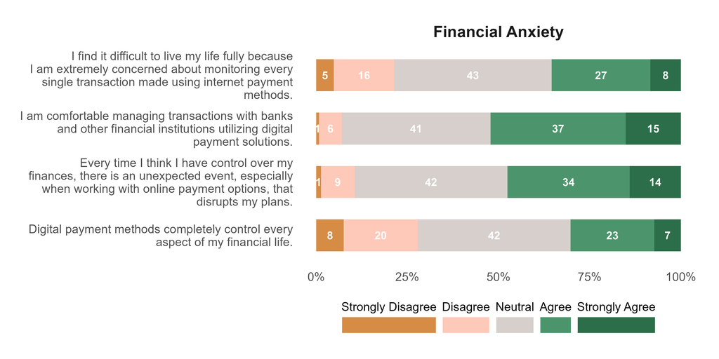

```r
p_finance_anxiety <- plot_factor("Financial Anxiety")

## saving plot
ggsave(
  plot = p_finance_anxiety,
  filename = "plot/fct_finance_anxiety.jpeg",
  width = 10,
  height = 5,
  dpi = 400,
  unit = "in"
)

## display plot
knitr::include_graphics("plot/fct_finance_anxiety.jpeg")
```

### Financial Capability

**TipInterpretation**

- 37% agree and 16% strongly agree they can save time and money using the digital financial landscape. However, 38% are neutral and 9% disagree, showing that while many recognize efficiency, a large group remains undecided.
- 32% agree and 11% strongly agree they are organized when using digital platforms. Yet, nearly half (46%) are neutral and 11% disagree, suggesting that confidence in organization is weaker compared to other capability items.
- Stronger consensus here: 42% agree and 25% strongly agree they set aside money for emergencies. Only 7% disagree, making this the most consistently positive capability indicator.
- 35% agree and 16% strongly agree they can balance spending and saving with digital tools. Still, 41% are neutral and 9% disagree, indicating mixed confidence in applying digital tools for financial discipline.

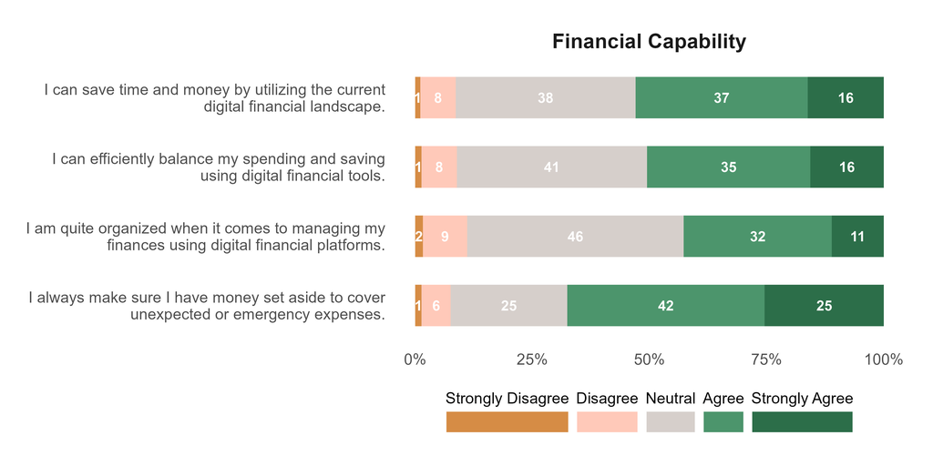

```r
p_finance_capability <- plot_factor("Financial Capability")

## saving plot
ggsave(
  plot = p_finance_capability,
  filename = "plot/fct_finance_capability.jpeg",
  width = 10,
  height = 5,
  dpi = 400,
  unit = "in"
)

## display plot
knitr::include_graphics("plot/fct_finance_capability.jpeg")
```

### Financial Satisfaction

**TipInterpretation**

- 27% agree and 7% strongly agree that they rarely run out of money, but 37% are neutral and 29% disagree/strongly disagree. This shows that while some students feel financially stable, a large portion experience uncertainty or frequent shortfalls.
- Only 24% agree/strongly agree they could obtain a loan if needed, while 38% are neutral and 39% disagree/strongly disagree. Indicates limited confidence in digital borrowing options, reflecting either lack of access or skepticism about eligibility.
- 37% agree and 11% strongly agree they can find products that meet their needs. However, 43% are neutral and 10% disagree/strongly disagree, suggesting that while many recognize available options, a significant group remains undecided about their suitability.

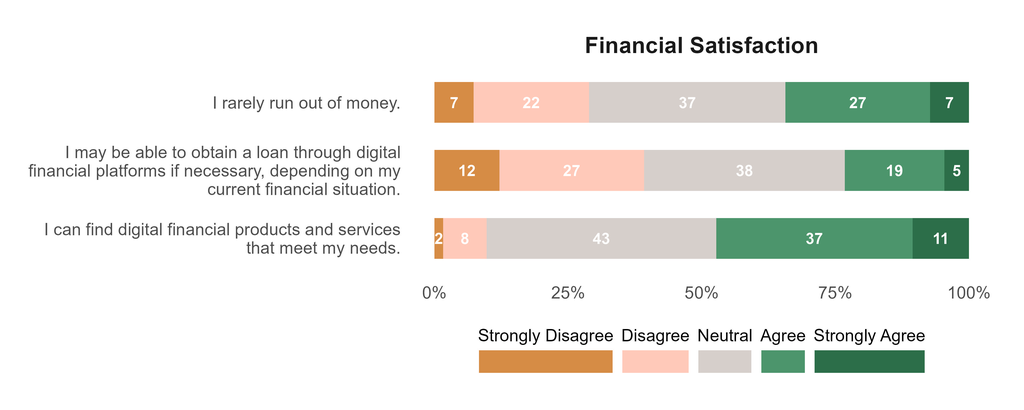

```r
p_finance_sat <- plot_factor("Financial Satisfaction")

## saving plot
ggsave(
  plot = p_finance_sat,
  filename = "plot/fct_finance_sat.jpeg",
  width = 10,
  height = 4,
  dpi = 400,
  unit = "in"
)

## display plot
knitr::include_graphics("plot/fct_finance_sat.jpeg")
```

### Financial Self-Efficacy

**TipInterpretation**

- 44% agree and 20% strongly agree they are confident in managing their funds. Still, 33% are neutral, showing that while many feel capable, a sizable group remains unsure.
- 40% agree and 22% strongly agree they can keep monthly expenses below income/allowance. About 31% are neutral and 8% disagree, indicating mixed consistency in practicing financial discipline.
- 39% agree and 17% strongly agree they can plan for the future using savings in banks or digital services.Yet, 37% are neutral and 6% disagree, reflecting partial confidence in long-term financial planning.
- 42% agree and 15% strongly agree they use digital financial skills efficiently to manage goals. However, 38% are neutral and 5% disagree, suggesting that while many apply digital skills, others are uncertain about their effectiveness.

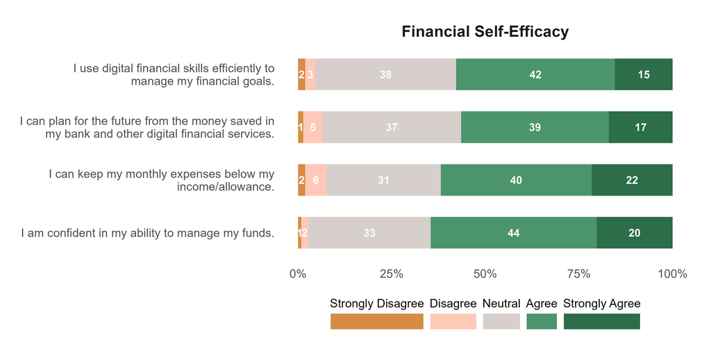

```r
p_fiance_self_efficacy <- plot_factor("Financial Self-Efficacy")

## saving plot
ggsave(
  plot = p_fiance_self_efficacy,
  filename = "plot/fct_fiance_self_efficacy.jpeg",
  width = 10,
  height = 5,
  dpi = 400,
  unit = "in"
)

## display plot
knitr::include_graphics("plot/fct_fiance_self_efficacy.jpeg")
```

### Practical Know-How

**TipInterpretation**

- 35% agree and 39% strongly agree they know how to open accounts on digital financial platforms. Only 4% disagree/strongly disagree, while 23% are neutral.
- 36% agree and 21% strongly agree they can navigate digital financial service applications. 37% are neutral, and 7% disagree/strongly disagree. The result indicates good competence, but neutrality suggests some students may not yet be fully comfortable with platform features.
- 34% agree and 25% strongly agree they can initiate, complete, or correct transactions. 34% are neutral, while 7% disagree/strongly disagree.
- Confidence is strong, but neutrality again highlights a group that may lack hands-on experience.

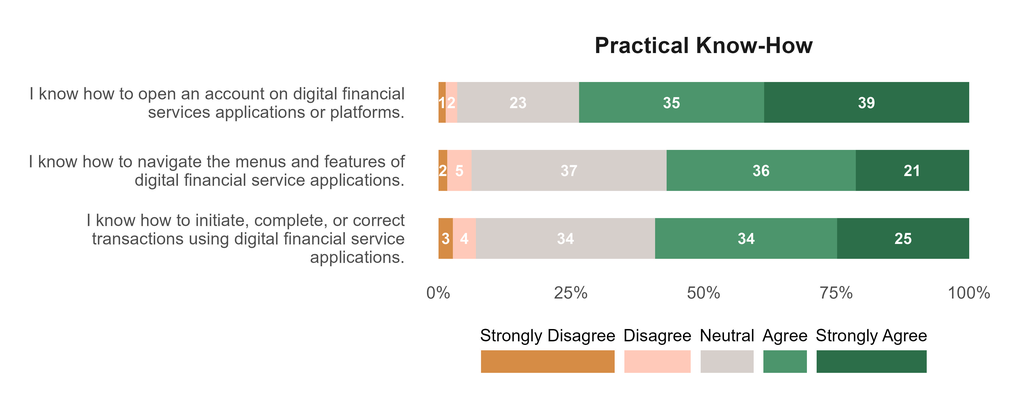

```r
p_practical_know_how <- plot_factor("Practical Know-How")

## saving plot
ggsave(
  plot = p_practical_know_how,
  filename = "plot/fct_practical_know_how.jpeg",
  width = 10,
  height = 4,
  dpi = 400,
  unit = "in"
)

## display plot
knitr::include_graphics("plot/fct_practical_know_how.jpeg")
```

### Self-Protection

**TipInterpretation**

- 38% agree and 29% strongly agree they read and understand terms to avoid deceptive practices. Still, 24% are neutral and 8% disagree/strongly disagree, showing that while many are cautious, a notable group may overlook or skim important details.
- 40% agree and 32% strongly agree they can recognize scams such as phishing or identity theft. About 25% are neutral, and only 4% disagree/strongly disagree, indicating strong awareness but with some uncertainty among a quarter of respondents.
- 40% agree and 46% strongly agree they actively protect their information when using digital financial services. Only 11% are neutral and 3% disagree/strongly disagree, making this the strongest self-protection behavior reported.

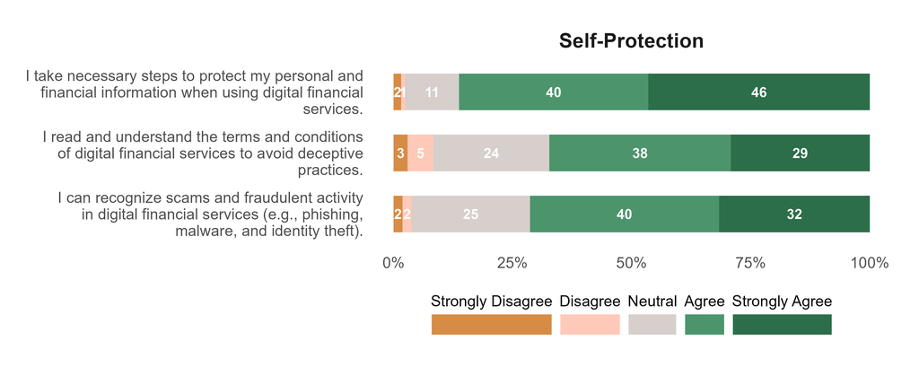

```r
p_self_protection <- plot_factor("Self-Protection")

## saving plot
ggsave(
  plot = p_self_protection,
  filename = "plot/fct_self_protection.jpeg",
  width = 10,
  height = 4,
  dpi = 400,
  unit = "in"
)

## display plot
knitr::include_graphics("plot/fct_self_protection.jpeg")
```

# 3 Objective 2-4: Examine whether digital financial literacy and self-efficacy is positively associated with financial well-being.

## 3.1 Correlation analysis

Guide interpretation of the correlation coefficients [@Akoglu2018].

| Correlation coefficient | Psychology | Politics and economics | Medicine |
| --- | --- | --- | --- |
| ± 1.0 | Perfect | Perfect | Perfect |
| ± 0.9 | Strong | Very strong | Very strong |
| ± 0.8 | Strong | Very strong | Very strong |
| ± 0.7 | Strong | Very strong | Moderate |
| ± 0.6 | Moderate | Strong | Moderate |
| ± 0.5 | Moderate | Strong | Fair |
| ± 0.4 | Moderate | Strong | Fair |
| ± 0.3 | Weak | Moderate | Fair |
| ± 0.2 | Weak | Weak | Poor |
| ± 0.1 | Weak | Negligible | Poor |
| ± 0.0 | Zero | None | None |

**TipInterpretation**

```r
## function for significance
fun_corr = function(x) {
  out = correlation(x, method = "pearson")
  stars = c("*" = .10, "**" = .05, "***" = .01)
  p = modelsummary:::make_stars(out$p, stars)
  out$r = sprintf("%.3f%s", out$r, p)
  out = as.matrix(out)
  return(out)
}

note_pvalue <- "Significance level: * p < 0.10, ** p < 0.05, *** p < 0.01"

## correlation
modelsummary::datasummary_correlation(
  data = fct_digi_fin_dta,
  output = "kableExtra",
  method = fun_corr,
  notes = note_pvalue
)
```

|  | Basic Knowledge and Skills | Awareness | Practical Know-How | Decision-making | Self-protection | Financial Self-Efficacy | Financial Satisfaction | Financial Capability | Financial Anxiety |
| --- | --- | --- | --- | --- | --- | --- | --- | --- | --- |
| Basic Knowledge and Skills | 1 | .598*** | .559*** | .425*** | .440*** | .261*** | .185*** | .278*** | .215*** |
| Awareness | .598*** | 1 | .689*** | .557*** | .660*** | .419*** | .131** | .383*** | .249*** |
| Practical Know-How | .559*** | .689*** | 1 | .560*** | .608*** | .484*** | .220*** | .439*** | .313*** |
| Decision-making | .425*** | .557*** | .560*** | 1 | .646*** | .625*** | .279*** | .551*** | .372*** |
| Self-protection | .440*** | .660*** | .608*** | .646*** | 1 | .525*** | .138** | .466*** | .339*** |
| Financial Self-Efficacy | .261*** | .419*** | .484*** | .625*** | .525*** | 1 | .405*** | .644*** | .434*** |
| Financial Satisfaction | .185*** | .131** | .220*** | .279*** | .138** | .405*** | 1 | .508*** | .351*** |
| Financial Capability | .278*** | .383*** | .439*** | .551*** | .466*** | .644*** | .508*** | 1 | .542*** |
| Financial Anxiety | .215*** | .249*** | .313*** | .372*** | .339*** | .434*** | .351*** | .542*** | 1 |

Significance level: * p < 0.10, ** p < 0.05, *** p < 0.01

[figure not shown]

```r
cor_mat <- round(cor(fct_digi_fin_dta, method = "pearson"), 3)
cor_mat[lower.tri(cor_mat)] <- NA
melted_cormat <- melt(cor_mat)

str_wrap_factor <- function(x, ...) {
  levels(x) <- str_wrap(levels(x), ...)
  x
}

melted_cormat_heatmap <-
  melted_cormat %>%
  mutate(
    Var2 = fct_rev(Var2),
    Var1 = factor(Var1),
    Var1 = str_wrap_factor(Var1, width = 32)
  ) %>%
  na.omit()

label_data <-
  melted_cormat_heatmap %>%
  count(Var1) %>%
  mutate(
    Var1 = as.character(Var1),
    Var2 = unique(melted_cormat_heatmap$Var2)
  ) %>%
  mutate(
    x_labs = c("BKS", "ADFS", "PKH", "DM", "SP", "FSE", "FS", "FC", "FA") %>%
      rev()
  )

p_corr_items <- melted_cormat_heatmap %>%
  ggplot(aes(x = Var2, y = Var1, fill = value)) +
  geom_tile() +
  geom_text(aes(label = value), color = "white", fontface = "bold") +
  geom_text(
    data = label_data,
    aes(label = Var1, y = Var1, x = -0.1),
    inherit.aes = F,
    size = 4,
    fontface = "bold",
    vjust = 0.5,
    hjust = 1
  ) +
  geom_text(
    data = label_data,
    aes(label = x_labs, y = 0, x = Var2),
    inherit.aes = F,
    vjust = 0,
    fontface = "bold",
    color = "grey20"
  ) +
  geom_text(
    data = label_data,
    aes(label = x_labs, y = Var1, x = 0.1),
    inherit.aes = F,
    angle = 90,
    vjust = 1,
    fontface = "bold",
    color = "grey20"
  ) +
  scale_fill_gradient(
    low = "#eaf4f4",
    high = "#264653",
    limit = c(0, 1),
    space = "Lab"
  ) +
  scale_x_discrete(position = "top") +
  guides(fill = guide_colorbar(title.position = "bottom", title.hjust = 0.5)) +
  coord_cartesian(clip = "off") +
  theme_minimal() +
  theme(
    plot.margin = margin(20, 20, 20, 180),
    plot.caption.position = "panel",
    plot.caption = element_text(
      hjust = 1,
      margin = margin(t = 20),
      size = 12,
      color = "grey20",
      lineheight = 1.1
    ),
    panel.grid = element_blank(),
    axis.text = element_blank(),
    legend.position = "bottom",
    legend.key.width = unit(10, "mm"),
    legend.direction = "horizontal",
    legend.title = element_text(size = 14),
    legend.text = element_text(size = 10)
  ) +
  labs(fill = "Spearman correlation", x = element_blank(), y = element_blank())

ggsave(
  plot = p_corr_items,
  filename = "plot/corr_items.jpeg",
  dpi = 300,
  width = 10,
  height = 6
)
knitr::include_graphics("plot/corr_items.jpeg")
```

# 4 Objective 5: Determine whether financial self-efficacy mediates the relationship between digital financial literacy and financial well-being.

## 4.1 Exploratory factor analysis

Exploratory Factor Analysis (EFA) is an essential preliminary step before moving into Partial Least Squares Structural Equation Modeling (PLS-SEM). The reason is that PLS-SEM assumes that the measurement model is already well-defined. EFA helps establish and validate this foundation.

1. Identify underlying constructs
- EFA reveals how survey items naturally cluster together, showing whether they measure the intended latent variables (e.g., digital financial literacy, self-efficacy, well-being).
- Without this step, there’s a risk of forcing items into constructs that don’t truly fit.
2. Determine the number of factors
- Through techniques like parallel analysis and scree plots, EFA helps decide how many latent constructs should be retained.
- This ensures that the PLS-SEM model is built on a structure that reflects the actual data rather than assumptions.
3. Check item loadings and validity
- EFA highlights which items load strongly on a factor and which may cross-load or fail to contribute meaningfully.
- This step improves the reliability and validity of constructs before they are tested in SEM.
4. Reduce measurement error
- By refining constructs through EFA, the subsequent PLS-SEM analysis produces more accurate path estimates and stronger conclusions.
- In short, EFA cleans and organizes the measurement model so SEM can focus on testing relationships among constructs.

```r
efa_lkrt_dta <-
  df |>
  select(bks1:fa4)
```

### 4.1.1 Parallel analysis

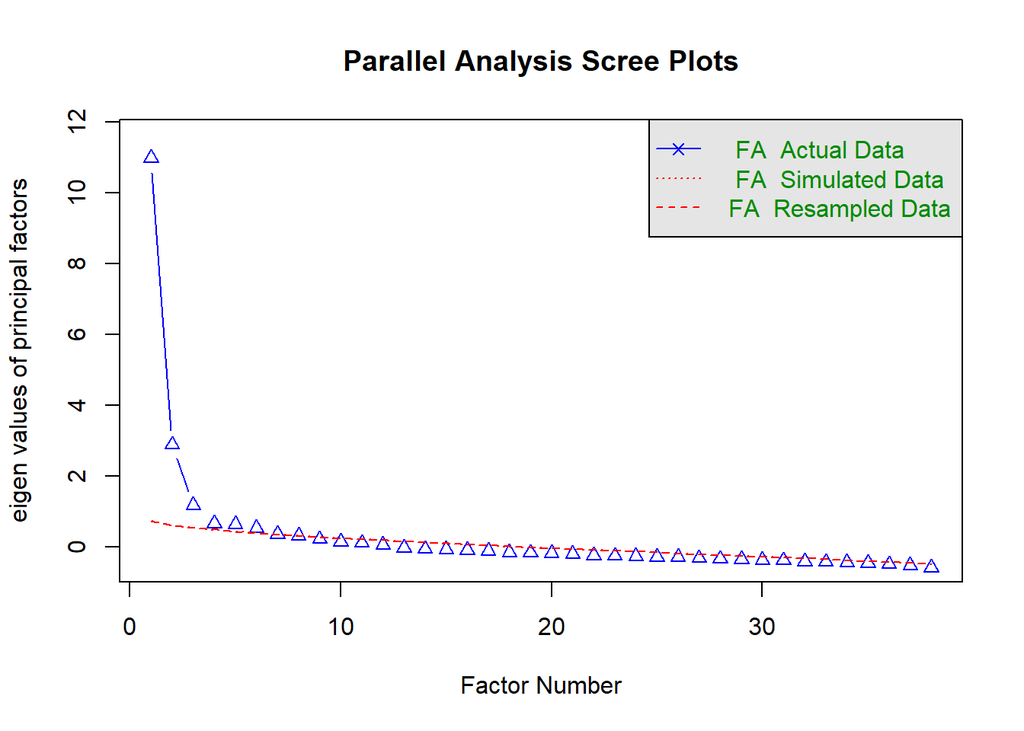

```
Parallel analysis suggests that the number of factors =  6  and the number of components =  NA
```

```r
fa.parallel(efa_lkrt_dta, fa = "fa")
```

### 4.1.2 Factor extraction

```r
sem_digi_finance_dta <-
  df |>
  select(bks1:fa4) |>
  select(
    -dm1,
    -dm2,
    -sp1,
    -dm3,
    -fs1,
    -fs2,
    -fs3,
    -fc1,
    -fc3,
    -fa1,
    -pkh2,
    -pkh3,
    -fc2,
    -bks1,
    -bks2,
    -bks3,
    -bks4,
    -bks5,
    -bks6,
    -bks7,
    -bks11,
    -sp2,
    -fse4,
    -fc4
  )
```

```r
efa_extract <- fa(
  sem_digi_finance_dta,
  nfactors = 6,
  rotate = "varimax",
  fm = "ml"
)

print(efa_extract$loadings, cutoff = 0.3, sort = TRUE)
```

```
Loadings:
      ML3    ML4    ML2    ML1    ML6    ML5
bks8   0.833
bks9   0.794
bks10  0.634
adfs1  0.773
adfs2  0.815                              0.360
adfs3  0.779
sp3    0.646  0.309
fse1          0.737
fse2          0.796
fse3          0.690
fa3                  0.990
pkh1   0.584                0.768
fa2                  0.496
fa4                  0.440         0.469

                 ML3   ML4   ML2   ML1   ML6   ML5
SS loadings    4.475 2.021 1.511 0.749 0.331 0.284
Proportion Var 0.320 0.144 0.108 0.054 0.024 0.020
Cumulative Var 0.320 0.464 0.572 0.625 0.649 0.669
```

## 4.2 PLS-SEM

**TipDigital financial literacy → Financial self-efficacy (β = 0.419, p < 0.001)**

- This path is strong and highly significant.
- Students with higher digital financial literacy are more confident in their ability to manage finances.
- The effect size is substantial, with a tight confidence interval [0.307, 0.529], confirming robustness.
- Digital skills and awareness directly build financial confidence

**TipDigital financial literacy → Financial well-being (β = 0.064, p = 0.372)**

- This path is weak and not significant.
- The coefficient is small and the confidence interval [-0.086, 0.206] crosses zero, meaning no reliable direct effect.
- Result shows digital financial literacy alone does not directly improve financial well-being. Instead, its influence is likely indirect, mediated through self-efficacy.

**TipFinancial self-efficacy → Financial well-being (β = 0.296, p < 0.001)**

- This path is moderate and significant.
- Students who feel confident in managing their finances report higher financial well-being.
- The confidence interval [0.162, 0.424] confirms stability of the effect.
- Result shows self-efficacy is a key driver of financial well-being, acting as the bridge between literacy and outcomes.

**TipIndirect Effect: Digital Financial Literacy → Financial Well-Being (via Financial Self-Efficacy)**

- Coefficient (β = 0.124, p < 0.001) .The indirect path is positive and statistically significant.
- This means that digital financial literacy contributes to financial well-being through the mediating role of financial self-efficacy.
- Students with stronger digital financial literacy skills tend to develop higher financial self-efficacy (confidence in managing finances).
- This increased self-efficacy, in turn, leads to better financial well-being outcomes. In other words, literacy alone does not directly improve well-being (as seen in the weak direct path), but when it builds confidence, the benefits become clear and significant.

### 4.2.1 Bootstrapped PLS-SEM model

```r
# Define measurement model
measurement_model <- constructs(
  composite(
    "Digital financial literacy",
    multi_items(
      c(rep("bks", 3), rep("adfs", 3), "pkh", "sp"),
      c(8:10, 1:3, 1, 3)
    )
  ),
  composite("Financial self-efficacy", multi_items("fse", 1:3)),
  composite("Financial well-being", multi_items("fa", 2:4))
)

# Define structural model
structural_model <- relationships(
  paths(
    from = "Digital financial literacy",
    to = c("Financial self-efficacy", "Financial well-being")
  ),
  paths(from = "Financial self-efficacy", to = "Financial well-being")
)

# Estimate the PLS model
pls_model <- estimate_pls(
  data = sem_digi_finance_dta,
  measurement_model = measurement_model,
  structural_model = structural_model
)

## summary of pls model
summ_pls_model <- summary(pls_model)

# Run bootstrapping (e.g., 5000 resamples, 4 cores for speed)
boot_pls <- bootstrap_model(
  seminr_model = pls_model,
  nboot = 5000,
  seed = 202604,
  cores = 4
)

## plot model
plot(boot_pls)
```

[interactive chart not shown]

#### 4.2.1.1 Direct effects

```r
## summary table
summ_boot_pls_model <- summary(boot_pls)

DT::datatable(summ_boot_pls_model$bootstrapped_paths |> round(3))
```

|  | Original Est. | Bootstrap Mean | Bootstrap SD | T Stat. | 2.5% CI | 97.5% CI | Bootstrap P Val |
| --- | --- | --- | --- | --- | --- | --- | --- |
| Digital financial literacy -&gt; Financial self-efficacy | 0.419 | 0.423 | 0.057 | 7.32 | 0.307 | 0.529 | 0 |
| Digital financial literacy -&gt; Financial well-being | 0.064 | 0.067 | 0.074 | 0.858 | -0.086 | 0.206 | 0.372 |
| Financial self-efficacy -&gt; Financial well-being | 0.296 | 0.298 | 0.066 | 4.489 | 0.162 | 0.424 | 0 |

#### 4.2.1.2 Indirect effects

```r
DT::datatable(round(summ_boot_pls_model$bootstrapped_total_indirect_paths, 3))
```

|  | Original Est. | Bootstrap Mean | Bootstrap SD | T Stat. | 2.5% CI | 97.5% CI | Bootstrap P Val |
| --- | --- | --- | --- | --- | --- | --- | --- |
| Digital financial literacy -&gt; Financial well-being | 0.124 | 0.126 | 0.031 | 3.956 | 0.068 | 0.191 | 0 |

### 4.2.2 Reliability test

**TipReliabilty indicators**

- **Digital Financial Literacy**
  - All values exceed the thresholds (α, rhoA, rhoC > 0.7; AVE > 0.5).
  - Excellent reliability and convergent validity. The items consistently measure the construct and capture sufficient variance.
- **Financial Self-Efficacy**
  - All values exceed thresholds, with AVE well above 0.5.
  - Strong reliability and validity. The construct is measured consistently and explains a large portion of variance in its indicators.
- **Financial Well-Being**
  - Cronbach’s Alpha and rhoA are slightly below 0.7, but Composite Reliability and AVE meet the criteria.
  - Acceptable reliability. While internal consistency is marginally lower, the construct still demonstrates adequate composite reliability and convergent validity. This suggests the items capture the concept but may be somewhat heterogeneous.

```r
DT::datatable(round(summ_pls_model$reliability, 3))
```

|  | alpha | rhoA | rhoC | AVE |
| --- | --- | --- | --- | --- |
| Digital financial literacy | 0.922 | 0.942 | 0.936 | 0.648 |
| Financial self-efficacy | 0.811 | 0.819 | 0.888 | 0.726 |
| Financial well-being | 0.68 | 0.684 | 0.823 | 0.607 |

### 4.2.3 Validity test

**TipFornell-Larcker Criterion**

- **Diagonal values (√AVE)**
  - Digital financial literacy = 0.805
  - Financial self-efficacy = 0.852
  - Financial well-being = 0.779
  - These represent the square root of AVE for each construct. They should be greater than the correlations with other constructs to confirm discriminant validity.
- **Comparisons with correlations**
  - **Digital financial literacy (0.805)** is higher than its correlations with financial self-efficacy (0.419) and financial well-being (0.188). DFL is distinct from the other constructs.
  - **Financial self-efficacy (0.852)** is higher than its correlations with digital financial literacy (0.419) and financial well-being (0.323). FSE is also distinct and well-separated.
  - **Financial well-being (0.779)** is higher than its correlations with digital financial literacy (0.188) and financial self-efficacy (0.323). FWB is distinct, though its correlation with FSE is moderately strong, which makes sense given the mediation role.

```r
DT::datatable(round(summ_pls_model$validity$fl_criteria, 3))
```

|  | Digital financial literacy | Financial self-efficacy | Financial well-being |
| --- | --- | --- | --- |
| Digital financial literacy | 0.805 |  |  |
| Financial self-efficacy | 0.419 | 0.852 |  |
| Financial well-being | 0.188 | 0.323 | 0.779 |

## 4.3 PLS-SEM with Higher-order

```r
## data
hoc_digi_finance_dta <-
  df |>
  select(bks1:fa4)

# Define measurement model with higher-order constructs
measurement_model <- constructs(
  # Digital Financial Literacy (HOC) with sub-dimensions
  composite("Basic knowledge and skills", multi_items("bks", 1:11)),
  composite("Awareness", multi_items("adfs", 1:3)),
  composite("Practical know-how", multi_items("pkh", 1:3)),
  composite("Decision-making", multi_items("dm", 1:3)),
  composite("Self-protection", multi_items("sp", 1:3)),

  higher_composite(
    "Digital financial literacy",
    dimensions = c(
      "Basic knowledge and skills",
      "Awareness",
      "Practical know-how",
      "Decision-making",
      "Self-protection"
    )
  ),

  # Financial Self-Efficacy
  composite("Financial self-efficacy", multi_items("fse", 1:4)),

  # Financial Well-Being (HOC) with sub-dimensions
  composite("Financial satisfaction", multi_items("fs", 1:3)),
  composite("Financial capability", multi_items("fc", 1:4)),
  composite("Financial anxiety", multi_items("fa", 1:4)),

  higher_composite(
    "Financial well-being",
    dimensions = c(
      "Financial satisfaction",
      "Financial capability",
      "Financial anxiety"
    )
  )
)

# Define structural model
structural_model <- relationships(
  paths(
    from = "Digital financial literacy",
    to = c("Financial self-efficacy", "Financial well-being")
  ),
  paths(from = "Financial self-efficacy", to = "Financial well-being")
)

# Estimate the PLS model
pls_model <- estimate_pls(
  data = hoc_digi_finance_dta,
  measurement_model = measurement_model,
  structural_model = structural_model
)

# Summarize results
summ_pls_model <- summary(pls_model)

# Bootstrapping (5000 resamples, 4 cores)
boot_pls <- bootstrap_model(
  seminr_model = pls_model,
  nboot = 5000,
  seed = 202604,
  cores = 4
)

# Plot bootstrapped model
plot(boot_pls)
```

[interactive chart not shown]

#### 4.3.0.1 Direct effects

```r
## summary table
summ_boot_pls_model <- summary(boot_pls)

DT::datatable(summ_boot_pls_model$bootstrapped_paths |> round(3))
```

|  | Original Est. | Bootstrap Mean | Bootstrap SD | T Stat. | 2.5% CI | 97.5% CI | Bootstrap P Val |
| --- | --- | --- | --- | --- | --- | --- | --- |
| Digital financial literacy -&gt; Financial self-efficacy | 0.621 | 0.627 | 0.042 | 14.868 | 0.539 | 0.702 | 0 |
| Digital financial literacy -&gt; Financial well-being | 0.235 | 0.247 | 0.09 | 2.629 | 0.062 | 0.407 | 0.006 |
| Financial self-efficacy -&gt; Financial well-being | 0.505 | 0.498 | 0.073 | 6.948 | 0.358 | 0.636 | 0 |

#### 4.3.0.2 Indirect effects

```r
DT::datatable(round(summ_boot_pls_model$bootstrapped_total_indirect_paths, 3))
```

|  | Original Est. | Bootstrap Mean | Bootstrap SD | T Stat. | 2.5% CI | 97.5% CI | Bootstrap P Val |
| --- | --- | --- | --- | --- | --- | --- | --- |
| Digital financial literacy -&gt; Financial well-being | 0.314 | 0.311 | 0.042 | 7.428 | 0.227 | 0.391 | 0 |

### 4.3.1 Reliability test

```r
DT::datatable(round(summ_pls_model$reliability, 3))
```

|  | alpha | rhoA | rhoC | AVE |
| --- | --- | --- | --- | --- |
| Digital financial literacy | 0.895 | 0.903 | 0.922 | 0.702 |
| Financial self-efficacy | 0.836 | 0.84 | 0.89 | 0.67 |
| Financial well-being | 0.769 | 0.814 | 0.866 | 0.683 |
| Basic knowledge and skills | 0.639 | 0.72 | 0.666 | 0.254 |
| Awareness | 0.896 | 0.901 | 0.935 | 0.828 |
| Practical know-how | 0.894 | 0.899 | 0.934 | 0.825 |
| Decision-making | 0.759 | 0.77 | 0.862 | 0.676 |
| Self-protection | 0.815 | 0.816 | 0.89 | 0.731 |
| Financial satisfaction | 0.57 | 0.619 | 0.769 | 0.53 |
| Financial capability | 0.796 | 0.801 | 0.868 | 0.624 |

[output cut: 1 more lines]

### 4.3.2 Validity test

```r
DT::datatable(round(summ_pls_model$validity$fl_criteria, 3))
```

|  | Digital financial literacy | Financial self-efficacy | Financial well-being | Basic knowledge and skills | Awareness | Practical know-how | Decision-making | Self-protection | Financial satisfaction | Financial capability | Financial anxiety |
| --- | --- | --- | --- | --- | --- | --- | --- | --- | --- | --- | --- |
| Digital financial literacy | 0.838 |  |  |  |  |  |  |  |  |  |  |
| Financial self-efficacy | 0.621 | 0.818 |  |  |  |  |  |  |  |  |  |
| Financial well-being | 0.549 | 0.651 | 0.827 |  |  |  |  |  |  |  |  |
| Basic knowledge and skills | 0.844 | 0.47 | 0.439 | 0.504 |  |  |  |  |  |  |  |
| Awareness | 0.847 | 0.427 | 0.373 | 0.72 | 0.91 |  |  |  |  |  |  |
| Practical know-how | 0.833 | 0.492 | 0.465 | 0.659 | 0.69 | 0.908 |  |  |  |  |  |
| Decision-making | 0.825 | 0.636 | 0.542 | 0.61 | 0.55 | 0.552 | 0.822 |  |  |  |  |
| Self-protection | 0.84 | 0.53 | 0.444 | 0.582 | 0.67 | 0.617 | 0.642 | 0.855 |  |  |  |
| Financial satisfaction | 0.309 | 0.448 | 0.757 | 0.264 | 0.192 | 0.284 | 0.326 | 0.202 | 0.728 |  |  |
| Financial capability | 0.559 | 0.652 | 0.902 | 0.473 | 0.379 | 0.436 | 0.551 | 0.464 | 0.552 | 0.79 |  |

[output cut: 1 more lines]